# The Influence of Text Characteristics for Email Classification

## 2.5 Fitting Model in Log-odds

```r
model1 <- glm(yesno ~ crl.tot+dollar+bang+money+n000+make, data = email_clean,
             family = binomial(link = "logit"))
```

```r
summary(model1)
```

```
Call:
glm(formula = yesno ~ crl.tot + dollar + bang + money + n000 +
    make, family = binomial(link = "logit"), data = email_clean)

Coefficients:
            Estimate Std. Error z value Pr(>|z|)
(Intercept)  -1.6353     0.1229 -13.305  < 2e-16 ***
crl.tot       0.4408     0.1091   4.041 5.31e-05 ***
dollar        7.6895     1.5341   5.012 5.38e-07 ***
bang          2.7064     0.3319   8.154 3.52e-16 ***
money         6.2497     1.4239   4.389 1.14e-05 ***
n000          3.0324     1.0003   3.032  0.00243 **
make         -0.7299     0.5110  -1.428  0.15321
---
Signif. codes:  0 '***' 0.001 '**' 0.01 '*' 0.05 '.' 0.1 ' ' 1

(Dispersion parameter for binomial family taken to be 1)

    Null deviance: 1112.56  on 835  degrees of freedom
Residual deviance:  676.89  on 829  degrees of freedom
AIC: 690.89

Number of Fisher Scoring iterations: 7
```

```r
mod1coefs <- round(coef(model1), 2)
```

The fitted linear model 1 is
$$\begin{align}
\ln\left(\frac{p}{1-p}\right) &= \alpha + \beta_{crl.tot} \cdot \textrm{crl.tot} +\beta_{dollar} \cdot \textrm{dollar} +\beta_{bang} \cdot \textrm{bang} +\nonumber\\&\hspace{0.5cm}\beta_{money} \cdot \textrm{money} +\beta_{n000} \cdot \textrm{n000}+\beta_{make} \cdot \textrm{make} \nonumber\\&= -1.64 + 0.44 \cdot \textrm{crl.tot} +7.69 \cdot \textrm{dollar} +2.71 \cdot \textrm{bang} +6.25 \cdot \textrm{money} +3.03\cdot \textrm{n000}+-0.73\cdot \textrm{make} \nonumber
\end{align}$$

```r
model2 <- glm(yesno ~ crl.tot+dollar+bang+money+n000, data = email_clean,
             family = binomial(link = "logit"))
```

```r
summary(model2)
```

```
Call:
glm(formula = yesno ~ crl.tot + dollar + bang + money + n000,
    family = binomial(link = "logit"), data = email_clean)

Coefficients:
            Estimate Std. Error z value Pr(>|z|)
(Intercept)  -1.6825     0.1205 -13.965  < 2e-16 ***
crl.tot       0.4433     0.1091   4.064 4.82e-05 ***
dollar        7.7594     1.5318   5.065 4.08e-07 ***
bang          2.7319     0.3336   8.188 2.66e-16 ***
money         6.0386     1.4264   4.234 2.30e-05 ***
n000          2.9258     0.9853   2.970  0.00298 **
---
Signif. codes:  0 '***' 0.001 '**' 0.01 '*' 0.05 '.' 0.1 ' ' 1

(Dispersion parameter for binomial family taken to be 1)

    Null deviance: 1112.56  on 835  degrees of freedom
Residual deviance:  679.74  on 830  degrees of freedom
AIC: 691.74

Number of Fisher Scoring iterations: 7
```

```r
mod2coefs <- round(coef(model2), 3)
```

To interpret this fitted model, firstly we note that the baseline category for our binary response is no.

```r
levels(email$yesno)
```

```
[1] "n" "y"
```

This means that estimates from the logistic regression model are for a change on the log-odds scale for yes in comparison to the response baseline no.

We can extract the estimated coefficients to report the fitted model as follows. The fitted linear model 2 is
$$\begin{align}
\ln\left(\frac{p}{1-p}\right) &= \alpha + \beta_{crl.tot} \cdot \textrm{crl.tot} +\beta_{dollar} \cdot \textrm{dollar} +\beta_{bang} \cdot \textrm{bang} +\nonumber\\&\hspace{0.5cm}\beta_{money} \cdot \textrm{money} +\beta_{n000} \cdot \textrm{n000} \nonumber\\&= -1.683 + 0.443 \cdot \textrm{crl.tot} +7.759 \cdot \textrm{dollar} +2.732 \cdot \textrm{bang} +\\&6.039 \cdot \textrm{money} +2.926\cdot \textrm{n000} \nonumber
\end{align}$$
where $p=\text{Prob}(yes)$ and $1-p=\text{Prob}(no)$. Hence, the log-odds of the instructor being spam increase by 0.443 for every one unit increase in scaled total length of uninterrupted sequences of capitals, when keeping other variables constant. Similarly, for a percentage of total number of characters for dollar sign, exclamation mark, money, and 000 for every one unit increase separately, the log-odds of the instructor being spam increase by 7.759, 2.732, 6.039, and 2.926.

This provides us with a point estimate of how the log-odds changes with explanatory variables, however, we are also interested in producing a 95% confidence interval for these log-odds.

```r
confint(model2) %>%
  kable()
```

Table 3: Summary confident of model2 coefficient.

|  | 2.5 % | 97.5 % |
| --- | --- | --- |
| (Intercept) | -1.9244368 | -1.4516071 |
| crl.tot | 0.2317928 | 0.6615067 |
| dollar | 4.9002485 | 10.9144214 |
| bang | 2.1076416 | 3.4172730 |
| money | 3.5759084 | 9.2186829 |
| n000 | 1.2405795 | 5.1371909 |

Hence, by Table 3, the point estimate for crl.tot is 0.44, which has a corresponding 95% confidence interval of (0.23, 0.66). Similarly, the point estimate for dollar is 7.76, with a 95% confidence interval of (4.90, 10.91). For bang, the point estimate is 2.73, with a 95% confidence interval of (2.11, 3.42). For money, the point estimate is 6.04, with a 95% confidence interval of (3.58, 9.22). For n000, the point estimate is 2.93, with a 95% confidence interval of (1.24, 5.14). This can be displayed graphically in the Figure 8.

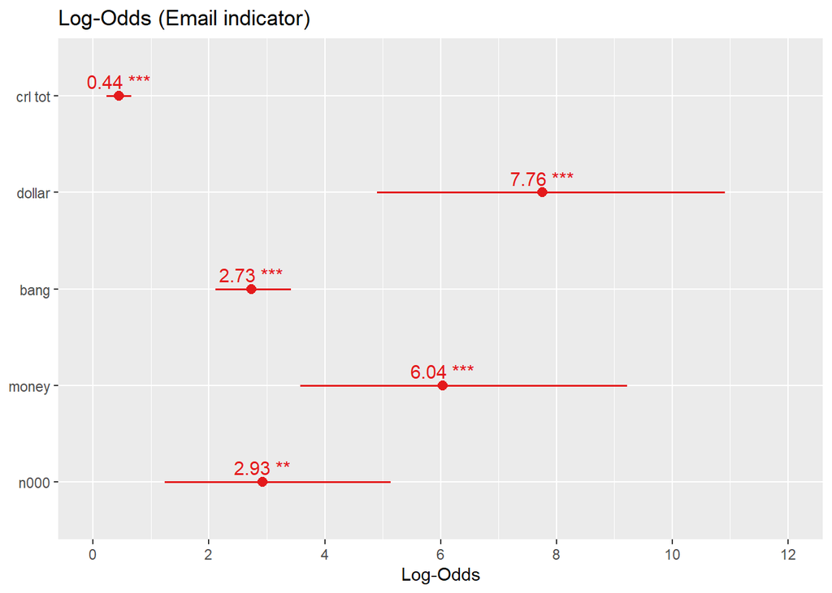

Figure 8: 95% CI of confidents in Log-odds.

```r
plot_model(model2, show.values = TRUE, transform = NULL,
           title = "Log-Odds (Email indicator)", show.p = TRUE)
```